# Homework #2

Jackie Yang

### Question 1: Consider the fitted regression equation y-hat = 100 + 15x. Answer below

### (a). What is the value of the sample slope?

### 15

### (b). What is the predicted response when x = 0?

### y-hat = 100

### (c). By how much is the response expected to increase for a unit increment of x?

### 15

### (d). If x is increase by 10 units, by how much would you expect the response to increase?

### 150

### Question 2: For which of the following regression assumption(s) cannot be verified from a residual plot?

### (a). Linearity (b). Constant variance (c). Independence (d). Zero mean

### Question 3: The number of calories and the grams of sugar per serving is measured for 36 breakfast cereals. The data is in the cereal.csv file. We are interested in predicting calories using the sugar content.

### (a). Make a scatterplot and comment on your observations

```r
read.csv(file = "Cereal.csv")
```

| Cereal | Calories | Sugar | Fiber |
| --- | --- | --- | --- |
| Common Sense Oat Bran | 100.0 | 6.0 | 3.0 |
| Product 19 | 100.0 | 3.0 | 1.0 |
| All Bran Xtra Fiber | 50.0 | 0.0 | 14.0 |
| Just Right | 140.0 | 9.0 | 2.0 |
| Original Oat Bran | 70.0 | 5.0 | 10.0 |
| Heartwise | 90.0 | 5.0 | 6.0 |
| Special K | 110.0 | 3.0 | 0.0 |
| Oatbake Raisin Nut | 110.0 | 8.0 | 2.0 |
| Kenmei Rice Bran | 150.0 | 9.0 | 2.0 |
| Nutri Grain | 100.0 | 2.0 | 3.0 |

[output cut: 26 more lines]

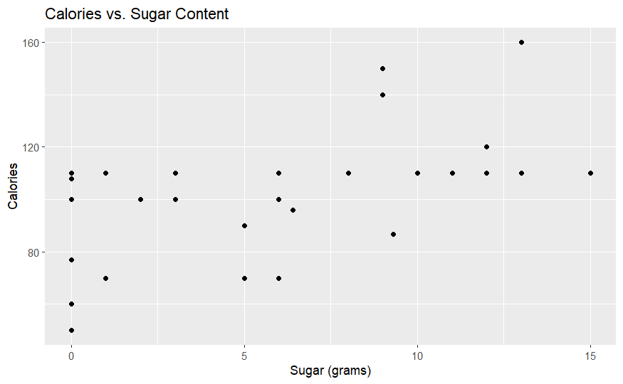

```r
cereal <- read.csv(file = "Cereal.csv")
ggplot(cereal, aes(x = Sugar, y = Calories)) + geom_point() + labs(x = "Sugar (grams)", y = "Calories", title = "Calories vs. Sugar Content")
```

### Observations: There seems to be a horizontal line that connects a lot of points (110 calories). This could indicate that sugar does not have an impact on calories. Some cereals have 0 grams of sugar but vary in amount of calories.

### (b). Find the least squares regression line for predicting calories based on the sugar content. Include your output and then write down (type) the least squares regression line

```r
lm(Calories ~ Sugar, data = cereal)
```

```
Call:
lm(formula = Calories ~ Sugar, data = cereal)

Coefficients:
(Intercept)        Sugar
     87.428        2.481
```

### y-hat = 2.481x + 87.428

### (c). Make a scatterplot and overlay the fitted regression model

[output not shown]

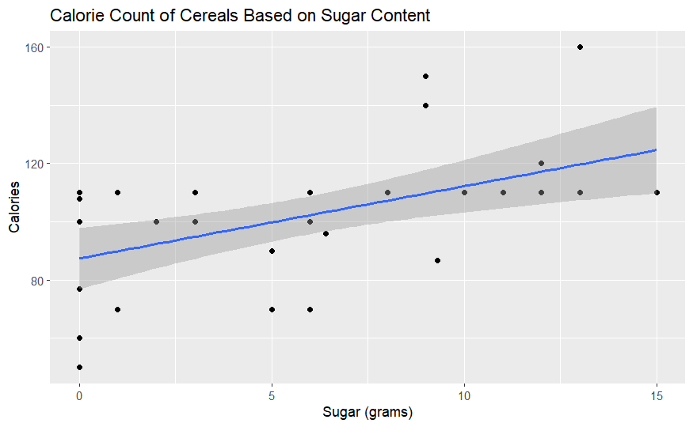

```r
ggplot(cereal, aes(x = Sugar, y = Calories)) + geom_point() + geom_smooth(method = 'lm') + labs(x = "Sugar (grams)", y = "Calories", title = "Calorie Count of Cereals Based on Sugar Content")
```

### (d). Interpret the slope in the context of this problem

### The slope is the predicted amount of caloric increase for each gram of sugar

### (e). Interpret the intercept in the context of this problem

### The intercept is the predicted amount of calories for cereal that contain 0 grams of sugar

### (f). Cheerios has 1 gram of sugar with 110 calories. Find the residual for this observation